# The weight of Pokémon species - Regression analyses considering type

Lara Lusa, Sam Manski, Marianne Huebner

July 2026

```r
Pokemon_clean$gender_cat <- factor(Pokemon_clean$gender_cat )
Pokemon_clean$gender_cat <-relevel(Pokemon_clean$gender_cat, ref = "Equal")
Pokemon_clean$happiness_cat <-relevel(factor(Pokemon_clean$happiness_cat), ref = "Normal")




mv_fit_step <- lm(formula = log2(weight_kg) ~ log2(height_m) + height_m + gender_cat +
    I(hp/10) + I(defense/10) + I(sp_attack/10) + I(speed/10) +
    special_status + happiness_cat, data = Pokemon_clean, x = T,
    y = T)
```

# Introduction

The aim of this analysis project is to study the variability in the weight of Pokémon species. The statistical analysis plan (SAP) specifies that linear regression models will be used to estimate the association between height and weight, both univariable and multivariable. The document Regression_Report addresses the problem with univariable and multivariable analyses.

In this document we assess also the association of type with the outcome. We assume that all the models described in the document Regression_Report were fitted and analyzed.

# Pokémon types

We start from the multivariable model selected with the backward AIC based method and we add the 18 Pokémon types as explanatory variables. Each type is defined as a binary variable, indicating if the species belongs or does not belong to the type. (See additional IDA report for more details about this variable).

```r
mv_fit_type <- update(mv_fit_step, .~. + is_rock +  is_dragon   + is_bug + is_steel + is_ground+ is_water+is_fire+is_grass+is_ice+is_flying+is_fairy+is_ghost+is_poison+is_electric+is_normal+is_dark+is_psychic+is_fighting)
summary(mv_fit_type) %>% tab_model()
```

|  | log 2(weight kg) |  |  |
| --- | --- | --- | --- |
| Predictors | Estimates | CI | p |
| (Intercept) | 4.31 | 3.81 – 4.81 | **<0.001** |
| height m [log2] | 1.73 | 1.60 – 1.86 | **<0.001** |
| height m | -0.31 | -0.40 – -0.21 | **<0.001** |
| gender cat [Mostly female] | -0.24 | -0.56 – 0.08 | 0.140 |
| gender cat [Mostly male] | 0.17 | -0.05 – 0.38 | 0.129 |
| gender cat [Genderless] | 0.45 | 0.14 – 0.75 | **0.004** |
| hp/10 | 0.12 | 0.08 – 0.15 | **<0.001** |
| defense/10 | 0.07 | 0.04 – 0.10 | **<0.001** |
| sp attack/10 | -0.04 | -0.07 – -0.01 | **0.019** |
| speed/10 | -0.04 | -0.07 – -0.01 | **0.021** |
| special status [sub-legendary] | -0.44 | -0.86 – -0.02 | **0.042** |
| special status [legendary] | 0.17 | -0.36 – 0.69 | 0.532 |
| special status [mythical] | -0.62 | -1.21 – -0.03 | **0.041** |
| happiness cat [Happy] | -0.38 | -0.84 – 0.08 | 0.103 |
| happiness cat [Unhappy] | 0.17 | -0.11 – 0.44 | 0.232 |
| is rock | 0.67 | 0.35 – 0.99 | **<0.001** |
| is dragon | 0.13 | -0.19 – 0.46 | 0.430 |
| is bug | -0.04 | -0.32 – 0.25 | 0.799 |
| is steel | 0.81 | 0.47 – 1.14 | **<0.001** |
| is ground | 0.40 | 0.10 – 0.71 | **0.010** |
| is water | -0.04 | -0.30 – 0.22 | 0.771 |
| is fire | 0.24 | -0.07 – 0.56 | 0.131 |
| is grass | -0.37 | -0.63 – -0.10 | **0.007** |
| is ice | 0.51 | 0.16 – 0.87 | **0.005** |
| is flying | -0.38 | -0.63 – -0.13 | **0.003** |
| is fairy | -0.62 | -0.96 – -0.28 | **<0.001** |
| is ghost | -1.11 | -1.44 – -0.78 | **<0.001** |
| is poison | -0.43 | -0.72 – -0.14 | **0.004** |
| is electric | 0.11 | -0.24 – 0.46 | 0.541 |
| is normal | 0.05 | -0.24 – 0.34 | 0.719 |
| is dark | 0.17 | -0.14 – 0.48 | 0.292 |
| is psychic | -0.04 | -0.33 – 0.26 | 0.806 |
| is fighting | 0.15 | -0.16 – 0.47 | 0.342 |
| Observations | 1025 |  |  |
| R<sup>2</sup> / R<sup>2</sup> adjusted | 0.760 / 0.752 |  |  |

**RESULTS:** Including type increases the R^2 (from 0.71 to 0.75) and decreases the residual standard error. Many types have a statistically significant association with weight. Rock, ice, steel and ground are statistically significantly positively associated, grass, flying, fairy, ghost and poison are statistically significantly negatively associated. The estimated coefficients of other explanatory variables change compared to the model without type, and the associations are generally attenuated (as might be expected, as type is associated to the other variables).

We fit also a model where the interaction between height (linear + log2) and all types are considered. The joint distribution of type and height was examined during IDA (see additional IDA report); no type was found to be so sparse or so narrowly distributed in height as to make its interaction term inestimable, though estimates for less numerous types are expected to be less precise. To limit the number of terms, backward elimination in the interaction model is performed based on AIC. The backward elimination drops both interactions together for a given type (pairwise), or none. The procedure only allows dropping a main effect after both interactions are eliminated (hierarchical rule).

```r
# first fit a model with all interactions between types and height

mv_fit_type_int <- lm(
  log2(weight_kg) ~ log2(height_m) + height_m + gender_cat +
    I(hp/10) + #I(attack/10) +
    I(defense/10) +
    I(sp_attack/10) + #I(sp_defense/10) +
    I(speed/10) +
    happiness_cat + special_status +
    is_rock + is_ice + is_dragon + is_bug + is_steel + is_ground +
    is_water + is_fire + is_grass + is_flying + is_fairy + is_ghost +
    is_poison + is_electric + is_normal + is_dark + is_psychic + is_fighting +
    # Interactions
    is_rock*log2(height_m) + is_ice*log2(height_m) + is_dragon*log2(height_m) +
    is_bug*log2(height_m) + is_steel*log2(height_m) + is_ground*log2(height_m) +
    is_water*log2(height_m) + is_fire*log2(height_m) + is_grass*log2(height_m) +
    is_flying*log2(height_m) + is_fairy*log2(height_m) + is_ghost*log2(height_m) +
    is_poison*log2(height_m) + is_electric*log2(height_m) + is_normal*log2(height_m) +
    is_dark*log2(height_m) + is_psychic*log2(height_m) + is_fighting*log2(height_m) +
    is_rock*height_m + is_ice*height_m + is_dragon*height_m +
    is_bug*height_m + is_steel*height_m + is_ground*height_m +
    is_water*height_m + is_fire*height_m + is_grass*height_m +
    is_flying*height_m + is_fairy*height_m + is_ghost*height_m +
    is_poison*height_m + is_electric*height_m + is_normal*height_m +
    is_dark*height_m + is_psychic*height_m + is_fighting*height_m,
  data = Pokemon_clean
)
```

```r
## -------------------------------
## Blocked, hierarchical backward AIC for type–height interactions
## -------------------------------

# types you use as 0/1 indicators in the model:
type_names <- c(
  "rock","ice","dragon","bug","steel","ground","water","fire","grass",
  "flying","fairy","ghost","poison","electric","normal","dark","psychic","fighting"
)

# helper: given term labels from terms(model), detect presence of main & interactions (either order)
present_terms_for_type <- function(terms_in_model, type) {
  main <- paste0("is_", type)
  int_lin_a  <- paste0("is_", type, ":height_m")
  int_lin_b  <- paste0("height_m:is_", type)
  int_log_a  <- paste0("is_", type, ":log2(height_m)")
  int_log_b  <- paste0("log2(height_m):is_", type)
  list(
    main_present   = main %in% terms_in_model,
    main_label     = main,
    lin_present    = any(c(int_lin_a, int_lin_b) %in% terms_in_model),
    lin_label      = intersect(c(int_lin_a, int_lin_b), terms_in_model),
    log2_present   = any(c(int_log_a, int_log_b) %in% terms_in_model),
    log2_label     = intersect(c(int_log_a, int_log_b), terms_in_model)
  )
}

# helper: update formula dropping a vector of exact term labels
drop_terms_from_formula <- function(fml, drops) {
  if (length(drops) == 0) return(fml)
  rhs <- paste(". ~ . -", paste(drops, collapse = " - "))
  update(fml, rhs)
}

# main routine
step_blocked_types <- function(model, data, type_names,
                               strict_pairs = TRUE, # if TRUE, only drop both interactions together
                               verbose = TRUE) {
  current_model <- model
  current_aic   <- AIC(current_model)

  log_df <- data.frame(iter = integer(), type = character(),
                       dropped = character(), old_AIC = numeric(),
                       new_AIC = numeric(), dAIC = numeric(),
                       stringsAsFactors = FALSE)

  improved <- TRUE
  iter <- 0
  while (improved) {
    iter <- iter + 1
    improved <- FALSE
    best_model <- current_model
    best_aic   <- current_aic
    best_drop  <- NULL
    best_type  <- NULL

    terms_in_model <- attr(terms(current_model), "term.labels")

    for (tp in type_names) {
      pres <- present_terms_for_type(terms_in_model, tp)

      # Which drops are allowed under hierarchy?

      # Case A: both interactions present -> propose dropping BOTH interactions together
      if (pres$lin_present && pres$log2_present) {
        drop_vec <- c(pres$lin_label, pres$log2_label)
        drop_vec <- unique(as.character(drop_vec))
        # Try dropping both interactions
        cand_formula <- drop_terms_from_formula(formula(current_model), drop_vec)
        cand_model   <- lm(cand_formula, data = data)
        cand_aic     <- AIC(cand_model)
        if (cand_aic < best_aic) {
          best_model <- cand_model
          best_aic   <- cand_aic
          best_drop  <- drop_vec
          best_type  <- tp
          improved   <- TRUE
        }
      } else {
        # Case B (optional): only one interaction present
        if (!strict_pairs) {
          # allow dropping whichever single interaction remains
          single <- unique(as.character(c(pres$lin_label, pres$log2_label)))
          single <- single[nchar(single) > 0]
          if (length(single) == 1) {
            cand_formula <- drop_terms_from_formula(formula(current_model), single)
            cand_model   <- lm(cand_formula, data = data)
            cand_aic     <- AIC(cand_model)
            if (cand_aic < best_aic) {
              best_model <- cand_model
              best_aic   <- cand_aic
              best_drop  <- single
              best_type  <- tp
              improved   <- TRUE
            }
          }
        }
      }

      # Case C: interactions absent, main present -> main is eligible for drop
      if (!pres$lin_present && !pres$log2_present && pres$main_present) {
        drop_vec <- pres$main_label
        cand_formula <- drop_terms_from_formula(formula(current_model), drop_vec)
        cand_model   <- lm(cand_formula, data = data)
        cand_aic     <- AIC(cand_model)
        if (cand_aic < best_aic) {
          best_model <- cand_model
          best_aic   <- cand_aic
          best_drop  <- drop_vec
          best_type  <- tp
          improved   <- TRUE
        }
      }

      # Case D: interactions present but main absent -> OK, we already handle dropping interactions above.
      # We never try to drop a main that isn't in the model.
    } # end for tp

    if (improved) {
      if (verbose) {
        cat(sprintf("Iter %d: drop (%s): %s   ΔAIC = %.3f\n",
                    iter, best_type, paste(best_drop, collapse=", "),
                    best_aic - current_aic))
      }
      log_df <- rbind(log_df, data.frame(
        iter = iter,
        type = best_type,
        dropped = paste(best_drop, collapse = ", "),
        old_AIC = current_aic,
        new_AIC = best_aic,
        dAIC = best_aic - current_aic,
        stringsAsFactors = FALSE
      ))
      current_model <- best_model
      current_aic   <- best_aic
    }
  } # while

  list(model = current_model, log = log_df)
}



# mv_fit_type_int (defined above) is the full model with all type×height interactions

# Example call (strict pair-drop on interactions):


res <- step_blocked_types(mv_fit_type_int, data = Pokemon_clean,
                          type_names = type_names,
                          strict_pairs = TRUE,  # only drop both interactions together
                          verbose = FALSE)

final_model <- res$model
cat("\nFinal AIC:", AIC(final_model), "\n")
```

```
##
## Final AIC: 3220.826
```

```r
summary(final_model)
```

```
##
## Call:
## lm(formula = cand_formula, data = data)
##
## Residuals:
##     Min      1Q  Median      3Q     Max
## -6.5434 -0.4987  0.0593  0.6100  9.7873
##
## Coefficients:
##                             Estimate Std. Error t value Pr(>|t|)
## (Intercept)                  4.54322    0.24120  18.836  < 2e-16 ***
## log2(height_m)               1.86438    0.07675  24.292  < 2e-16 ***
## height_m                    -0.42692    0.06363  -6.709 3.28e-11 ***
## gender_catMostly female     -0.25145    0.16052  -1.566 0.117560
## gender_catMostly male        0.15309    0.10425   1.468 0.142305
## gender_catGenderless         0.37678    0.15529   2.426 0.015428 *
## I(hp/10)                     0.11848    0.01805   6.565 8.39e-11 ***
## I(defense/10)                0.06845    0.01624   4.214 2.74e-05 ***
## I(sp_attack/10)             -0.04549    0.01573  -2.891 0.003919 **
## I(speed/10)                 -0.03462    0.01531  -2.261 0.023966 *
## happiness_catHappy          -0.37912    0.22732  -1.668 0.095674 .
## happiness_catUnhappy         0.25039    0.13138   1.906 0.056960 .
## special_statussub-legendary -0.37872    0.21211  -1.785 0.074494 .
## special_statuslegendary      0.09786    0.26297   0.372 0.709888
## special_statusmythical      -0.59544    0.29641  -2.009 0.044825 *
## is_rock                      0.54828    0.31453   1.743 0.081611 .
## is_ice                       0.46672    0.16784   2.781 0.005527 **
## is_steel                     0.81677    0.16128   5.064 4.88e-07 ***
## is_ground                    0.40066    0.14365   2.789 0.005387 **
## is_fire                      0.22605    0.14011   1.613 0.106972
## is_grass                    -0.39055    0.11434  -3.416 0.000662 ***
## is_flying                   -0.39868    0.12177  -3.274 0.001097 **
## is_fairy                    -0.62814    0.15963  -3.935 8.90e-05 ***
## is_ghost                    -2.12191    0.46886  -4.526 6.75e-06 ***
## is_poison                   -0.88010    0.19400  -4.537 6.41e-06 ***
## log2(height_m):is_rock      -0.37506    0.26858  -1.396 0.162882
## log2(height_m):is_ghost     -0.52935    0.26593  -1.991 0.046802 *
## log2(height_m):is_poison    -0.34475    0.18137  -1.901 0.057611 .
## height_m:is_rock             0.05965    0.22157   0.269 0.787800
## height_m:is_ghost            0.75234    0.33709   2.232 0.025846 *
## height_m:is_poison           0.31191    0.10161   3.070 0.002202 **
## ---
## Signif. codes:  0 '***' 0.001 '**' 0.01 '*' 0.05 '.' 0.1 ' ' 1
##
## Residual standard error: 1.146 on 994 degrees of freedom
## Multiple R-squared:  0.7637, Adjusted R-squared:  0.7566
## F-statistic: 107.1 on 30 and 994 DF,  p-value: < 2.2e-16
```

```r
res$log  # shows the elimination path
```

```
##    iter     type                                          dropped  old_AIC
## 1     1  psychic   height_m:is_psychic, log2(height_m):is_psychic 3269.676
## 2     2     dark         height_m:is_dark, log2(height_m):is_dark 3265.832
## 3     3   dragon     height_m:is_dragon, log2(height_m):is_dragon 3262.110
## 4     4   normal     height_m:is_normal, log2(height_m):is_normal 3258.506
## 5     5   ground     height_m:is_ground, log2(height_m):is_ground 3254.810
## 6     6 fighting height_m:is_fighting, log2(height_m):is_fighting 3251.738
## 7     7    fairy       height_m:is_fairy, log2(height_m):is_fairy 3248.676
## 8     8     fire         height_m:is_fire, log2(height_m):is_fire 3245.802
## 9     9    steel       height_m:is_steel, log2(height_m):is_steel 3243.768
## 10   10      ice           height_m:is_ice, log2(height_m):is_ice 3241.832
## 11   11  psychic                                       is_psychic 3239.830
## 12   12      bug           height_m:is_bug, log2(height_m):is_bug 3237.899
## 13   13      bug                                           is_bug 3236.010
## 14   14   normal                                        is_normal 3234.055
```

[output cut: 33 more lines]

```r
summary(final_model) %>% tab_model()
```

|  | Dependent variable |  |  |
| --- | --- | --- | --- |
| Predictors | Estimates | CI | p |
| (Intercept) | 4.54 | 4.07 – 5.02 | **<0.001** |
| log2(height_m) | 1.86 | 1.71 – 2.01 | **<0.001** |
| height_m | -0.43 | -0.55 – -0.30 | **<0.001** |
| gender_catMostly female | -0.25 | -0.57 – 0.06 | 0.118 |
| gender_catMostly male | 0.15 | -0.05 – 0.36 | 0.142 |
| gender_catGenderless | 0.38 | 0.07 – 0.68 | **0.015** |
| I(hp/10) | 0.12 | 0.08 – 0.15 | **<0.001** |
| I(defense/10) | 0.07 | 0.04 – 0.10 | **<0.001** |
| I(sp_attack/10) | -0.05 | -0.08 – -0.01 | **0.004** |
| I(speed/10) | -0.03 | -0.06 – -0.00 | **0.024** |
| happiness_catHappy | -0.38 | -0.83 – 0.07 | 0.096 |
| happiness_catUnhappy | 0.25 | -0.01 – 0.51 | 0.057 |
| special_statussub-legendary | -0.38 | -0.79 – 0.04 | 0.074 |
| special_statuslegendary | 0.10 | -0.42 – 0.61 | 0.710 |
| special_statusmythical | -0.60 | -1.18 – -0.01 | **0.045** |
| is_rock | 0.55 | -0.07 – 1.17 | 0.082 |
| is_ice | 0.47 | 0.14 – 0.80 | **0.006** |
| is_steel | 0.82 | 0.50 – 1.13 | **<0.001** |
| is_ground | 0.40 | 0.12 – 0.68 | **0.005** |
| is_fire | 0.23 | -0.05 – 0.50 | 0.107 |
| is_grass | -0.39 | -0.61 – -0.17 | **0.001** |
| is_flying | -0.40 | -0.64 – -0.16 | **0.001** |
| is_fairy | -0.63 | -0.94 – -0.31 | **<0.001** |
| is_ghost | -2.12 | -3.04 – -1.20 | **<0.001** |
| is_poison | -0.88 | -1.26 – -0.50 | **<0.001** |
| log2(height_m):is_rock | -0.38 | -0.90 – 0.15 | 0.163 |
| log2(height_m):is_ghost | -0.53 | -1.05 – -0.01 | **0.047** |
| log2(height_m):is_poison | -0.34 | -0.70 – 0.01 | 0.058 |
| height_m:is_rock | 0.06 | -0.38 – 0.49 | 0.788 |
| height_m:is_ghost | 0.75 | 0.09 – 1.41 | **0.026** |
| height_m:is_poison | 0.31 | 0.11 – 0.51 | **0.002** |
| Observations | 1025 |  |  |
| R<sup>2</sup> / R<sup>2</sup> adjusted | 0.764 / 0.757 |  |  |

**RESULTS:** The interactions retained in the model after variable selection are those for rock, ghost and poison. The main effects are those of rock, ice, steel, ground, fire, grass, flying, fairy, ghost and poison. The R2 is similar to that of the model without interactions.

The graphical presentation of the estimated association between height and weight among different types is shown below. The types that were omitted from variable selection are grouped in the Other class, the weight is estimated using the reference value for categorical variables and the median value for numerical variables.

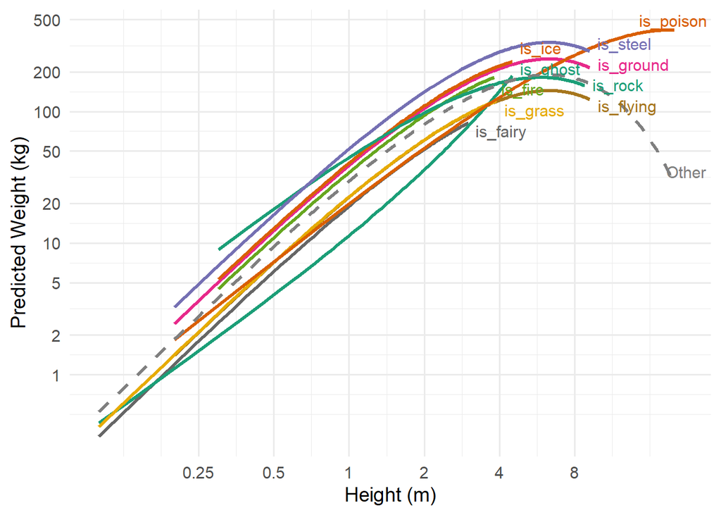

```r
library(dplyr)
library(ggplot2)
library(RColorBrewer)
library(scales)
library(ggrepel)

# --- 1. Define all types and those kept in final_model ---
all_types <- c("is_rock","is_ice","is_dragon","is_bug","is_steel","is_ground",
               "is_water","is_fire","is_grass","is_flying","is_fairy","is_ghost",
               "is_poison","is_electric","is_normal","is_dark","is_psychic","is_fighting")

kept_types <- intersect(all_types, attr(terms(final_model), "term.labels"))

# --- 2. Reference values for other predictors ---
ref_values <- Pokemon_clean %>%
  summarise(across(where(is.numeric), median, na.rm = TRUE))
ref_values$gender_cat        <- levels(Pokemon_clean$gender_cat)[1]
ref_values$happiness_cat     <- levels(Pokemon_clean$happiness_cat)[1]
ref_values$PokemonPhase_5cat <- levels(Pokemon_clean$PokemonPhase_5cat)[1]
ref_values$special_status <- levels(Pokemon_clean$special_status)[1]

# --- 3. Build predictions per type within observed ranges ---
pred_list <- list()

for (t in all_types) {
  obs_range <- Pokemon_clean %>%
    filter(.data[[t]] == 1) %>%
    summarise(min_h = min(height_m, na.rm = TRUE),
              max_h = max(height_m, na.rm = TRUE))

  if (nrow(obs_range) == 0 || is.na(obs_range$min_h)) next

  height_seq <- seq(obs_range$min_h, obs_range$max_h, length.out = 100)

  newdata <- data.frame(
    height_m = height_seq,
    log2_height_m = log2(height_seq)
  )

  for (col in setdiff(names(ref_values), c("height_m","log2_height_m"))) {
    newdata[[col]] <- ref_values[[col]]
  }

  for (tt in all_types) {
    newdata[[tt]] <- ifelse(tt == t, 1, 0)
  }

  newdata$type <- ifelse(t %in% kept_types, t, "Other")
  newdata$pred <- predict(final_model, newdata)
  newdata$pred_kg <- 2^(newdata$pred)
  newdata$line_type <- ifelse(newdata$type == "Other", "dashed", "solid")

  pred_list[[t]] <- newdata
}

pred_all <- bind_rows(pred_list)

# --- 4. Assign Dark2 colors ---
main_types <- unique(pred_all$type)
kept_colors <- brewer.pal(min(length(kept_types), 8), "Dark2")  # max 8 colors in Dark2
# If more than 8 kept types, repeat colors
kept_colors <- rep(kept_colors, length.out = length(kept_types))
colors_vec <- c(kept_colors, "gray50")  # last color for Other
names(colors_vec) <- c(kept_types, "Other")

# --- 5. Prepare labels at endpoints ---
end_points <- pred_all %>%
  group_by(type) %>%
  filter(height_m == max(height_m)) %>%
  ungroup()

# --- 6. Plot ---
ggplot(pred_all, aes(x = height_m, y = pred_kg, color = type, linetype = line_type)) +
  geom_line(size = 1.2) +
  geom_text_repel(data = end_points,
                  aes(label = type),
                  nudge_x = 0.1,
                  segment.color = NA,
                  direction = "y",
                  hjust = 0,
                  size = 4,
                  box.padding = 0.2,
                  max.overlaps = 20) +
  scale_x_continuous(trans = "log2",
                     breaks = c(0.25, 0.5, 1, 2, 4, 8),
                     labels = c("0.25","0.5","1","2","4","8")) +
  scale_y_continuous(trans = "log2",
                     breaks = c(1, 2, 5, 10, 20, 50, 100, 200, 500),
                     labels = c("1","2","5","10","20","50","100","200","500")) +
  scale_color_manual(values = colors_vec) +
  scale_linetype_identity() +
  labs(x = "Height (m)",
       y = "Predicted Weight (kg)") +
  theme_minimal(base_size = 14) +
  theme(legend.position = "none")
```